# more

Letian Lin

2025-02-13

```r
library(corrplot)
library(ggplot2)
library(dplyr)
library(gridExtra)
library("GGally")
library(tidyr)
```

```r
Sys.setlocale("LC_CTYPE", "en_US.UTF-8")
```

```
## [1] "en_US.UTF-8"
```

```r
data_railway <- read.csv("2020-11-15成渝高铁上行成都局1车在前3号弓_All.csv")
km298 <- data_railway[1562:5579,]
km299 <- data_railway[0:1561,]
```

上次这个地方弄错了，其实中间的点都缺失了而不是异常值（上次画折线图把中间两端连起来了，误以为有点）

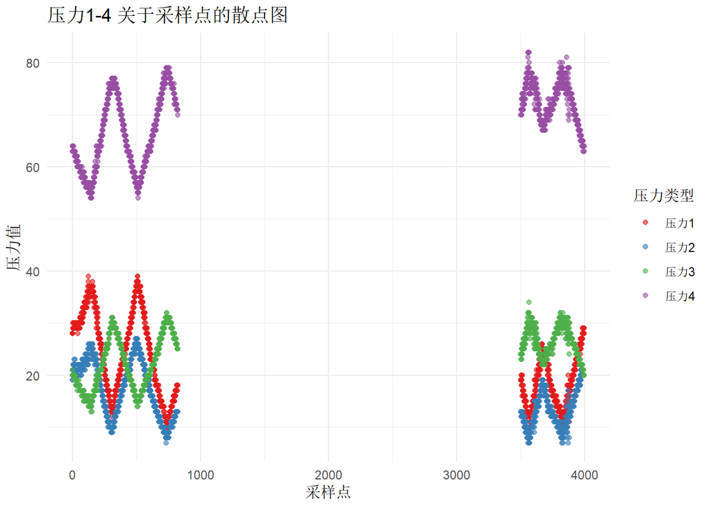

```r
data_long1 <- reshape(
     data = km299,
    varying = list(c("压力1", "压力2", "压力3", "压力4")),
     direction = "long",
     v.names = "Pressure_Value",
     timevar = "Pressure_Type",
     times = c("压力1", "压力2", "压力3", "压力4")
 )
ggplot(data_long1, aes(x = 采样点, y = Pressure_Value, color = Pressure_Type)) +
     geom_point(alpha = 0.6) +
     labs(
         title = "压力1-4 关于采样点的散点图",
         x = "采样点",
         y = "压力值",
         color = "压力类型"
     ) +
     theme_minimal() +
     scale_color_brewer(palette = "Set1")
```

```r
# 替换列名
colnames(km298) <- c(
  "WKm", "Samp", "P1", "P2", "P3", "P4",
  "VAB", "LAB", "Temp", "VA",
  "VA1", "VA2", "VA3", "VA4",
  "S1P", "S2P", "UC", "CC",
  "ACC", "HP", "Imp", "CDV", "CH",
  "NC", "NV", "LA", "LA1",
  "LA2", "LA3", "LA4", "SC",
  "SD", "R1", "R2", "R3", "R4", "Sp", "MM",
  "Sup", "NCH1", "NCH2", "NCDV1",
  "NCDV2", "NCW1", "NCW2", "CWG",
  "Sus", "Pow"
)
cor_matrix <- cor(km298%>% filter(P1 != 200))  # 计算相关系数矩阵
```

- 整公里数 -> WKm 采样点 -> Samp
- 压力1 -> P1, 压力2 -> P2, 压力3 -> P3, 压力4 -> P4
- 垂加基 -> VAB, 横加基 -> LAB
- 温度 -> Temp
- 垂加 -> VA, 垂加1 -> VA1, 垂加2 -> VA2, 垂加3 -> VA3, 垂加4 -> VA4
- 滑板1压力 -> S1P, 滑板2压力 -> S2P
- 无补偿接触力 -> UC, 有补偿接触力 -> CC, 空气动力补偿接触力 -> ACC
- 硬点 -> HP
- 冲击 -> Imp
- 接触拉出值 -> CDV, 接触导高 -> CH
- 网流 -> NC
- 网压 -> NV
- 纵加 -> LA, 纵加1 -> LA1, 纵加2 -> LA2, 纵加3 -> LA3, 纵加4 -> LA4
- 火花次数 -> SC, 火花时间 -> SD
- 保留1 -> R1, 保留2 -> R2, 保留3 -> R3, 保留4 -> R4
- 速度 -> Sp
- 公里标 -> MM
- 支柱 -> Sup
- 非接触导高1 -> NCH1, 非接触导高2 -> NCH2
- 非接触拉出值1 -> NCDV1, 非接触拉出值2 -> NCDV2
- 非接触磨耗1 -> NCW1, 非接触磨耗2 -> NCW2
- 接触线坡度 -> CWG
- 吊悬 -> Sus
- 功率 -> Pow

# 298km段的相关性热图

  这个相关性热图是298km段的，把缺失值（200或0填充的）去掉了。这里问号的原因是原来那张图因为有缺失值，某些列本来是常数（这里的计算相关性不包括常数，如果列为常数就显示问号），但是因为缺失值（比如列是常数-13180，缺失值填的0，会误认为有从0到-13180这个变化）

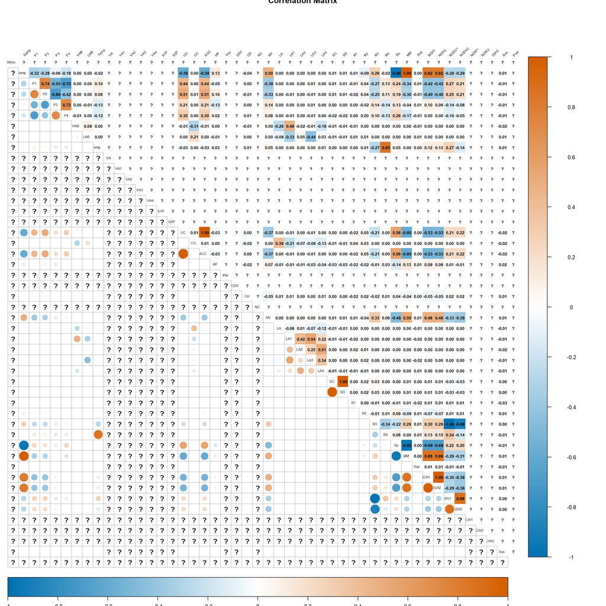

```r
options(repr.plot.width = 15, repr.plot.height = 15)  # 调整画布尺寸

# 自定义相关矩阵绘图
corrplot(
  cor_matrix,
  method = "color",                     # 上三角区域使用颜色填充
  col = colorRampPalette(c("#0072B2", "white", "#D55E00"))(200),
  addCoef.col = "black",                # 显示相关系数
  number.cex = 0.6,                     # 相关系数字体大小
  type = "upper",                       # 上三角显示相关系数
  diag = FALSE,                         # 不显示对角线
  tl.col = "black",                     # 标签颜色
  tl.cex = 0.5,
  tl.srt = 45,                          # 标签字体大小
  cl.cex = 0.8,                         # 图例字体大小
  title = "Correlation Matrix",         # 图表标题

)

# 下三角显示圆圈
corrplot(
  cor_matrix,
  method = "circle",                    # 下三角区域使用圆圈
  col = colorRampPalette(c("#0072B2", "white", "#D55E00"))(200),
  type = "lower",                       # 下三角显示圆圈
  add = TRUE,                           # 叠加图表
  diag = FALSE,                         # 不显示对角线
  tl.pos = "n",                         # 隐藏下三角的标签
  cl.pos = "b",                         # 图例位置（底部）
  cl.cex = 0.8                          # 图例字体大小
)
```

# 整个数据集直方图

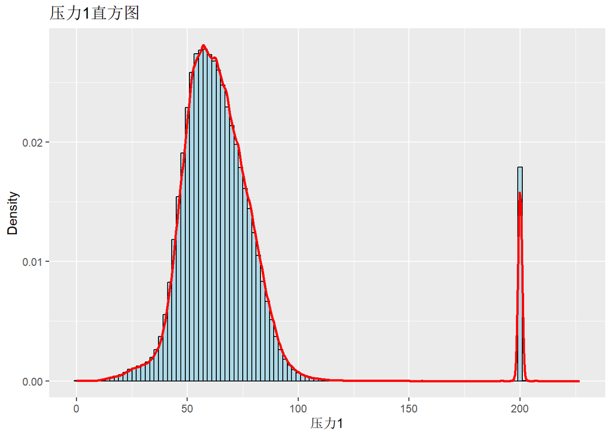

```r
ggplot(data_railway, aes(x = 压力1)) +
  geom_histogram(aes(y = ..density..), binwidth = 2, color = "black", fill = "lightblue") +
  geom_density(color = "red", size = 1) +
  labs(title = "压力1直方图", x = "压力1", y = "Density")
```

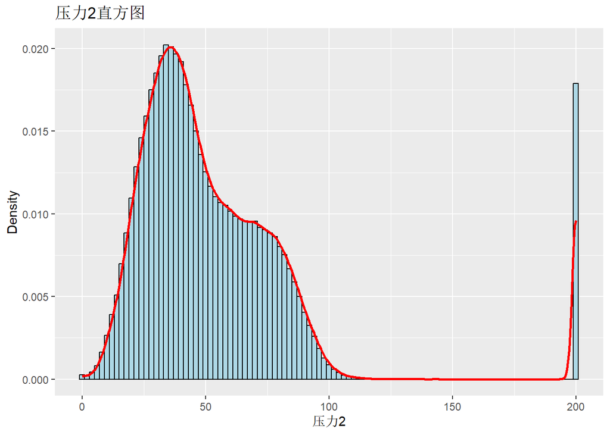

```r
ggplot(data_railway, aes(x = 压力2)) +
  geom_histogram(aes(y = ..density..), binwidth = 2, color = "black", fill = "lightblue") +
  geom_density(color = "red", size = 1) +
  labs(title = "压力2直方图", x = "压力2", y = "Density")
```

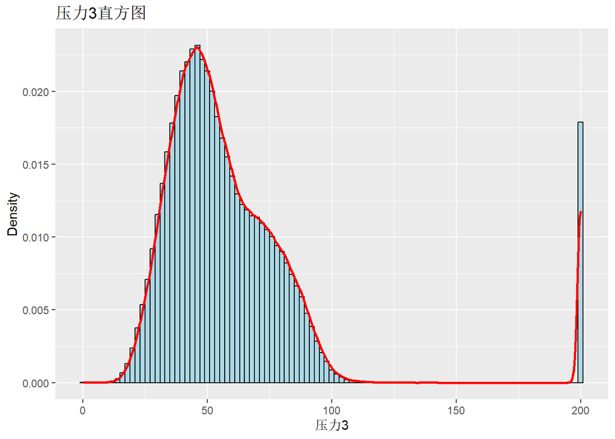

```r
ggplot(data_railway, aes(x = 压力3)) +
  geom_histogram(aes(y = ..density..), binwidth = 2, color = "black", fill = "lightblue") +
  geom_density(color = "red", size = 1) +
  labs(title = "压力3直方图", x = "压力3", y = "Density")
```

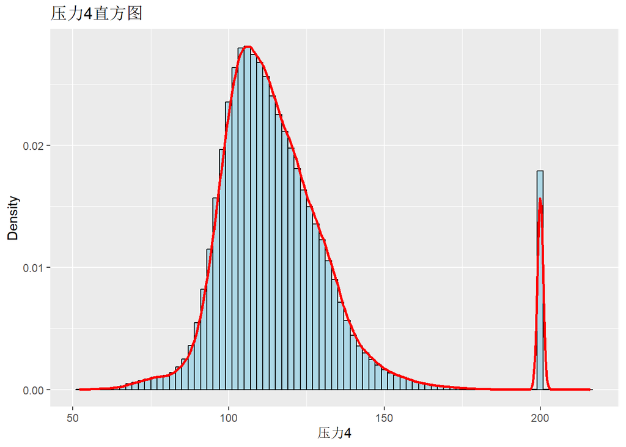

```r
ggplot(data_railway, aes(x = 压力4)) +
  geom_histogram(aes(y = ..density..), binwidth = 2, color = "black", fill = "lightblue") +
  geom_density(color = "red", size = 1) +
  labs(title = "压力4直方图", x = "压力4", y = "Density")
```

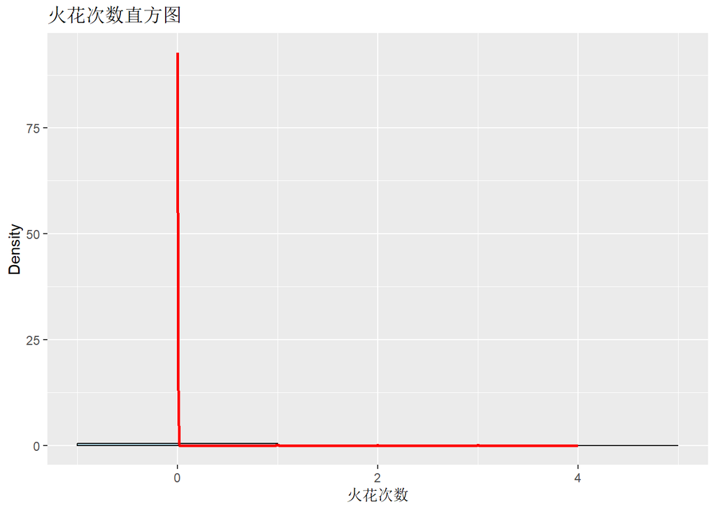

```r
ggplot(data_railway, aes(x = 火花次数)) +
  geom_histogram(aes(y = ..density..), binwidth = 2, color = "black", fill = "lightblue") +
  geom_density(color = "red", size = 1) +
  labs(title = "火花次数直方图", x = "火花次数", y = "Density")
```

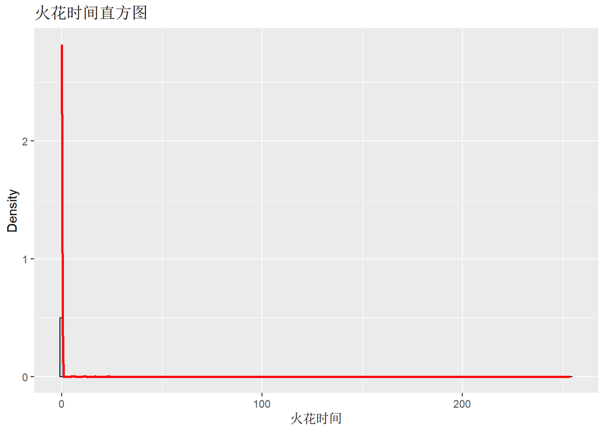

```r
ggplot(data_railway, aes(x = 火花时间)) +
  geom_histogram(aes(y = ..density..), binwidth = 2, color = "black", fill = "lightblue") +
  geom_density(color = "red", size = 1) +
  labs(title = "火花时间直方图", x = "火花时间", y = "Density")
```

# 298km段直方图

```r
km298 <- data_railway[1562:5579,]
summary(km298)
```

```
##     整公里数       采样点           压力1            压力2
##  Min.   :298   Min.   :   0.0   Min.   :  1.00   Min.   :  0.0
##  1st Qu.:298   1st Qu.: 713.2   1st Qu.: 19.00   1st Qu.: 13.0
##  Median :298   Median :1635.5   Median : 26.00   Median : 17.0
##  Mean   :298   Mean   :1651.3   Mean   : 39.61   Mean   : 32.3
##  3rd Qu.:298   3rd Qu.:2578.8   3rd Qu.: 32.00   3rd Qu.: 22.0
##  Max.   :298   Max.   :3504.0   Max.   :200.00   Max.   :200.0
##      压力3            压力4            垂加基           横加基
##  Min.   : 10.00   Min.   : 52.00   Min.   :-14336   Min.   :-18388.0
##  1st Qu.: 22.00   1st Qu.: 69.00   1st Qu.:     0   1st Qu.: -2840.0
##  Median : 26.00   Median : 74.00   Median :     0   Median :     0.0
##  Mean   : 40.28   Mean   : 83.91   Mean   :  3181   Mean   :  -114.1
##  3rd Qu.: 30.00   3rd Qu.: 79.00   3rd Qu.:   336   3rd Qu.:   614.0
##  Max.   :200.00   Max.   :200.00   Max.   : 30682   Max.   : 30681.0
##       温度              垂加            垂加1            垂加2
##  Min.   : 0.0000   Min.   :-13108   Min.   :-13108   Min.   :-13108
##  1st Qu.: 0.0000   1st Qu.:-13108   1st Qu.:-13108   1st Qu.:-13108
##  Median : 0.0000   Median :-13108   Median :-13108   Median :-13108
##  Mean   : 0.4955   Mean   :-11999   Mean   :-11999   Mean   :-11999
##  3rd Qu.: 0.0000   3rd Qu.:-13108   3rd Qu.:-13108   3rd Qu.:-13108
##  Max.   :47.0000   Max.   :     0   Max.   :     0   Max.   :     0
##      垂加3            垂加4          滑板1压力        滑板2压力
##  Min.   :-13108   Min.   :-13108   Min.   :  0.72   Min.   :  0.72
##  1st Qu.:-13108   1st Qu.:-13108   1st Qu.:  0.72   1st Qu.:  0.72
##  Median :-13108   Median :-13108   Median :  0.72   Median :  0.72
##  Mean   :-11999   Mean   :-11999   Mean   : 17.58   Mean   : 17.58
##  3rd Qu.:-13108   3rd Qu.:-13108   3rd Qu.:  0.72   3rd Qu.:  0.72
##  Max.   :     0   Max.   :     0   Max.   :200.00   Max.   :200.00
##   无补偿接触力    有补偿接触力    空气动力补偿接触力      硬点
##  Min.   : 99.0   Min.   :-77.68   Min.   : 99.0      Min.   :-4.0000
##  1st Qu.:135.0   1st Qu.:200.00   1st Qu.:135.0      1st Qu.: 0.0000
##  Median :141.0   Median :200.00   Median :141.0      Median : 0.0000
##  Mean   :146.7   Mean   :239.32   Mean   :146.7      Mean   :-0.1986
##  3rd Qu.:152.0   3rd Qu.:212.99   3rd Qu.:152.0      3rd Qu.: 0.0000
##  Max.   :200.0   Max.   :506.82   Max.   :200.0      Max.   : 3.0000
##       冲击          接触拉出值        接触导高          网流        网压
##  Min.   :  0.00   Min.   :-13108   Min.   :-7403   Min.   :0   Min.   :    0
##  1st Qu.:100.00   1st Qu.:-13108   1st Qu.: 9225   1st Qu.:0   1st Qu.:27823
##  Median :100.00   Median :-13108   Median : 9225   Median :0   Median :28044
##  Mean   : 91.54   Mean   :-11999   Mean   : 8388   Mean   :0   Mean   :25654
```

[output cut: 29 more lines]

```
##  Max.   :299.0   Max.   :1000.000   Max.   :5569   Max.   :5546
##  非接触拉出值1     非接触拉出值2      非接触磨耗1  非接触磨耗2   接触线坡度
##  Min.   :-412.00   Min.   :-412.00   Min.   :0    Min.   :0    Min.   :0
##  1st Qu.:-160.00   1st Qu.:-165.00   1st Qu.:0    1st Qu.:0    1st Qu.:0
##  Median : -32.00   Median : -45.00   Median :0    Median :0    Median :0
##  Mean   : -30.91   Mean   : -42.59   Mean   :0    Mean   :0    Mean   :0
##  3rd Qu.:  93.75   3rd Qu.:  79.75   3rd Qu.:0    3rd Qu.:0    3rd Qu.:0
##  Max.   : 349.00   Max.   : 323.00   Max.   :0    Max.   :0    Max.   :0
##       吊悬              功率
##  Min.   :   0.00   Min.   :0
##  1st Qu.:   0.00   1st Qu.:0
##  Median :   0.00   Median :0
##  Mean   :  27.13   Mean   :0
##  3rd Qu.:   0.00   3rd Qu.:0
##  Max.   :1000.00   Max.   :0
```

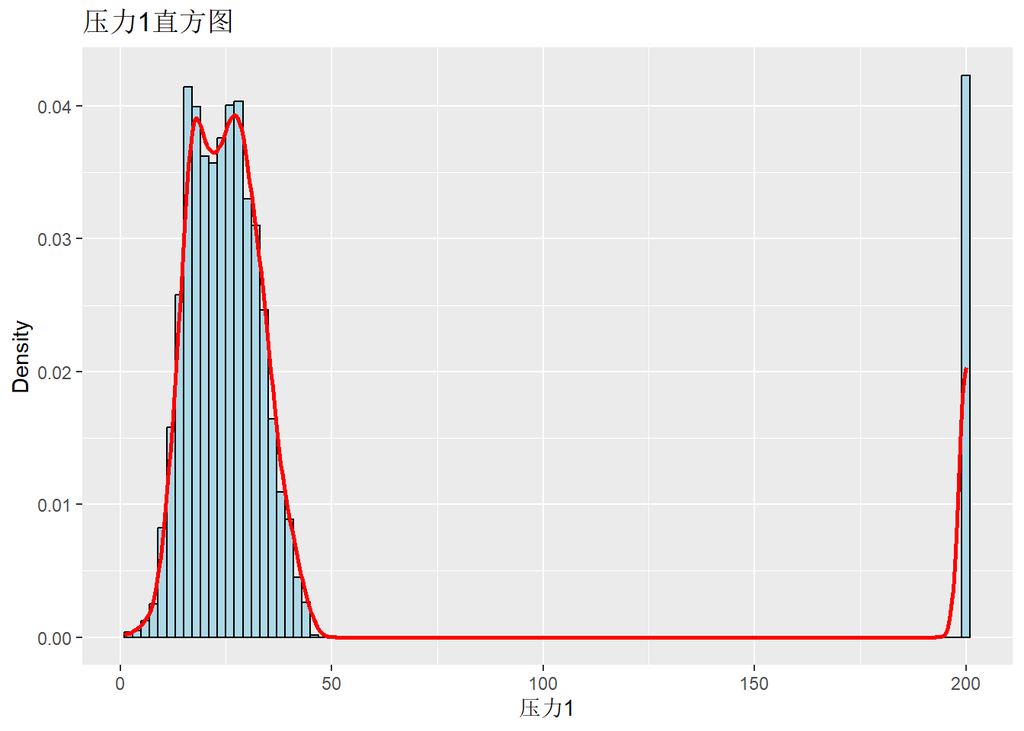

```r
ggplot(km298, aes(x = 压力1)) +
  geom_histogram(aes(y = ..density..), binwidth = 2, color = "black", fill = "lightblue") +
  geom_density(color = "red", size = 1) +
  labs(title = "压力1直方图", x = "压力1", y = "Density")
```

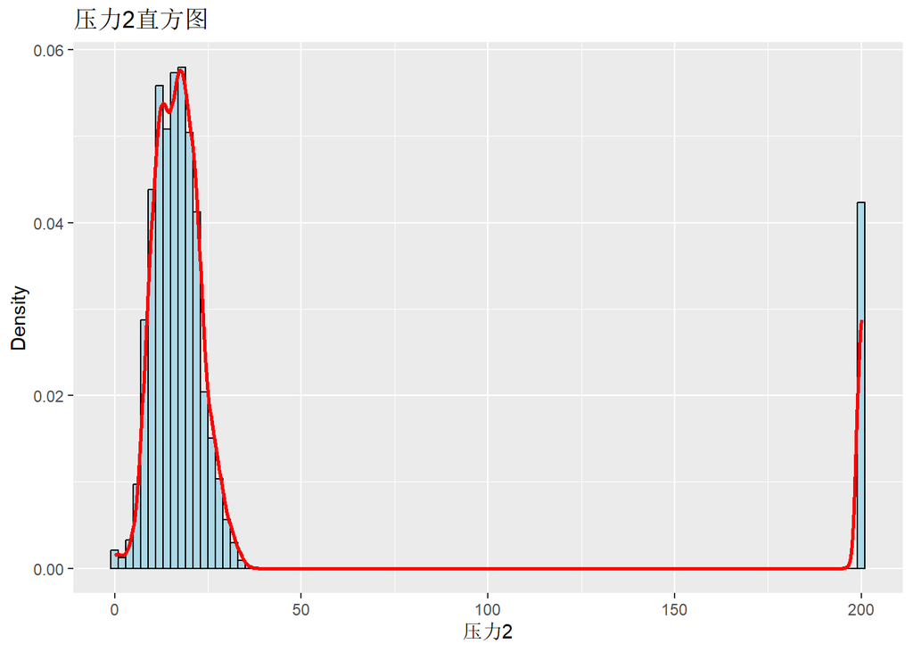

```r
ggplot(km298, aes(x = 压力2)) +
  geom_histogram(aes(y = ..density..), binwidth = 2, color = "black", fill = "lightblue") +
  geom_density(color = "red", size = 1) +
  labs(title = "压力2直方图", x = "压力2", y = "Density")
```

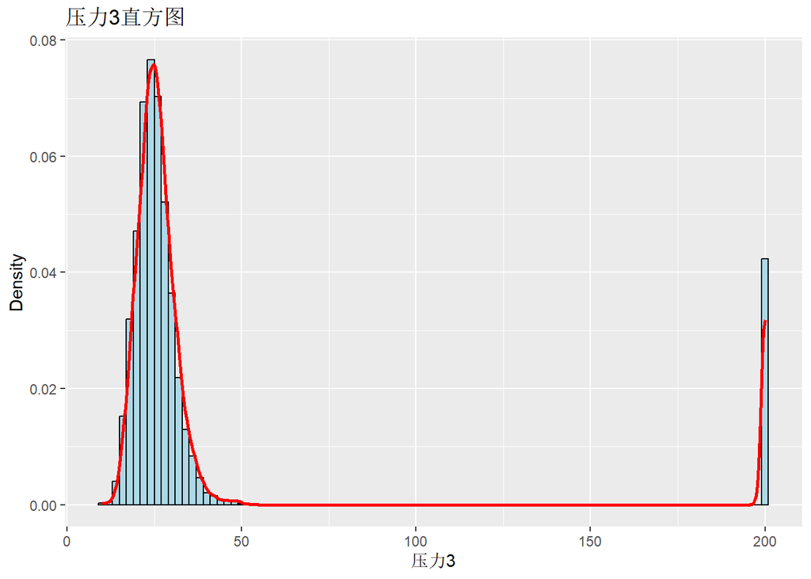

```r
ggplot(km298, aes(x = 压力3)) +
  geom_histogram(aes(y = ..density..), binwidth = 2, color = "black", fill = "lightblue") +
  geom_density(color = "red", size = 1) +
  labs(title = "压力3直方图", x = "压力3", y = "Density")
```

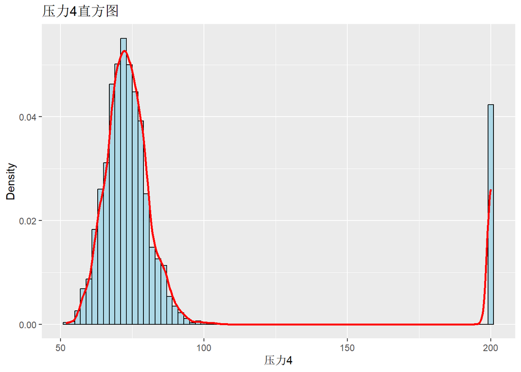

```r
ggplot(km298, aes(x = 压力4)) +
  geom_histogram(aes(y = ..density..), binwidth = 2, color = "black", fill = "lightblue") +
  geom_density(color = "red", size = 1) +
  labs(title = "压力4直方图", x = "压力4", y = "Density")
```

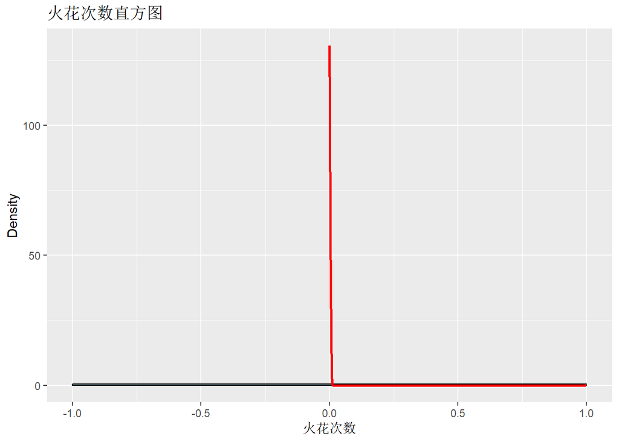

```r
ggplot(km298, aes(x = 火花次数)) +
  geom_histogram(aes(y = ..density..), binwidth = 2, color = "black", fill = "lightblue") +
  geom_density(color = "red", size = 1) +
  labs(title = "火花次数直方图", x = "火花次数", y = "Density")
```

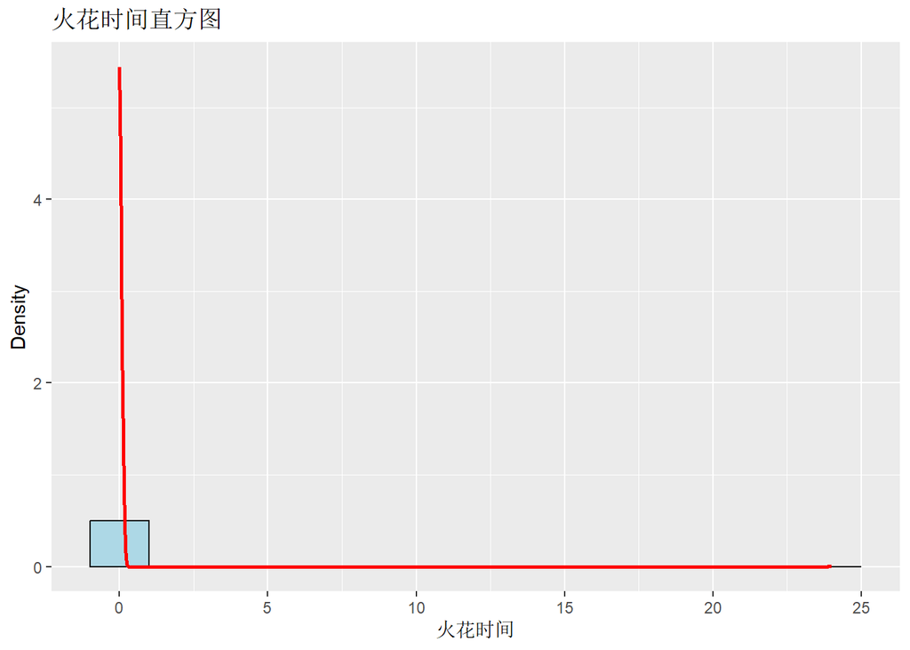

```r
ggplot(km298, aes(x = 火花时间)) +
  geom_histogram(aes(y = ..density..), binwidth = 2, color = "black", fill = "lightblue") +
  geom_density(color = "red", size = 1) +
  labs(title = "火花时间直方图", x = "火花时间", y = "Density")
```

### 根据上面298km的相关性热图, 下面把与压力1-4相关性大的散点图画出来

```r
data_long <- reshape(
  data = km298,
  varying = list(c("压力1", "压力2", "压力3", "压力4")),
  direction = "long",
  v.names = "Pressure_Value",
  timevar = "Pressure_Type",
  times = c("压力1", "压力2", "压力3", "压力4")
)
```

#### 压力1-4与无补偿接触力

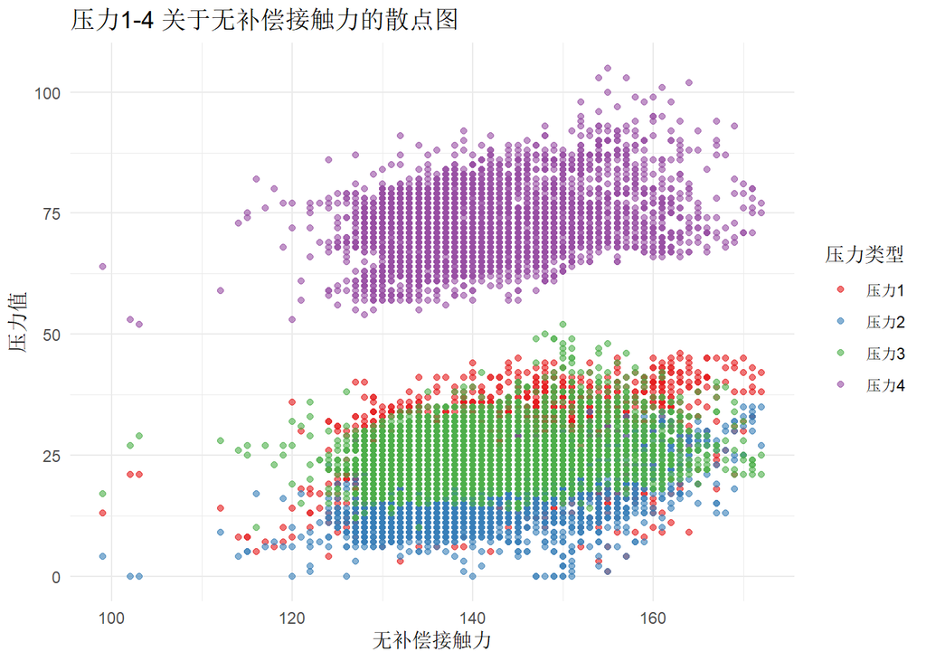

```r
ggplot(data_long %>% filter(Pressure_Value != 200), aes(x = 无补偿接触力, y = Pressure_Value, color = Pressure_Type)) +
  geom_point(alpha = 0.6) +
  labs(
    title = "压力1-4 关于无补偿接触力的散点图",
    x = "无补偿接触力",
    y = "压力值",
    color = "压力类型"
  ) +
  theme_minimal() +
  scale_color_brewer(palette = "Set1")
```

#### 压力1-4与空气动力补偿接触力

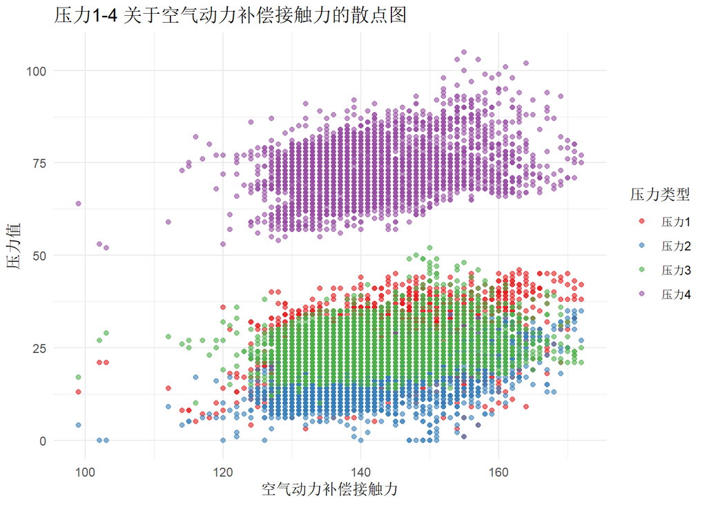

```r
ggplot(data_long %>% filter(Pressure_Value != 200), aes(x = 空气动力补偿接触力, y = Pressure_Value, color = Pressure_Type)) +
  geom_point(alpha = 0.6) +
  labs(
    title = "压力1-4 关于空气动力补偿接触力的散点图",
    x = "空气动力补偿接触力",
    y = "压力值",
    color = "压力类型"
  ) +
  theme_minimal() +
  scale_color_brewer(palette = "Set1")
```

#### 压力1-4与速度

压力1与速度的相关系数为0.24

压力2与速度的相关系数为0.19

压力4与速度的相关系数为0.26

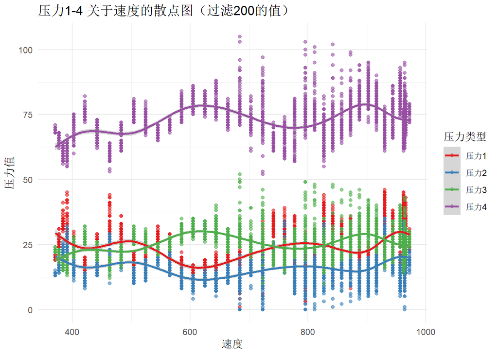

```r
ggplot(data_long %>% filter(Pressure_Value != 200),  # 关键修改：过滤200的值
       aes(x = 速度, y = Pressure_Value, color = Pressure_Type)) +
  geom_point(alpha = 0.6) +
  labs(
    title = "压力1-4 关于速度的散点图（过滤200的值）",
    x = "速度",
    y = "压力值",
    color = "压力类型"
  ) +
  theme_minimal() +
  scale_color_brewer(palette = "Set1") +
  geom_smooth()
```

#### 压力1-4与网压

压力1与网压的相关系数为-0.38

压力2与网压的相关系数为-0.33

压力3与网压的相关系数为0.14

压力4与网压的相关系数为0.08

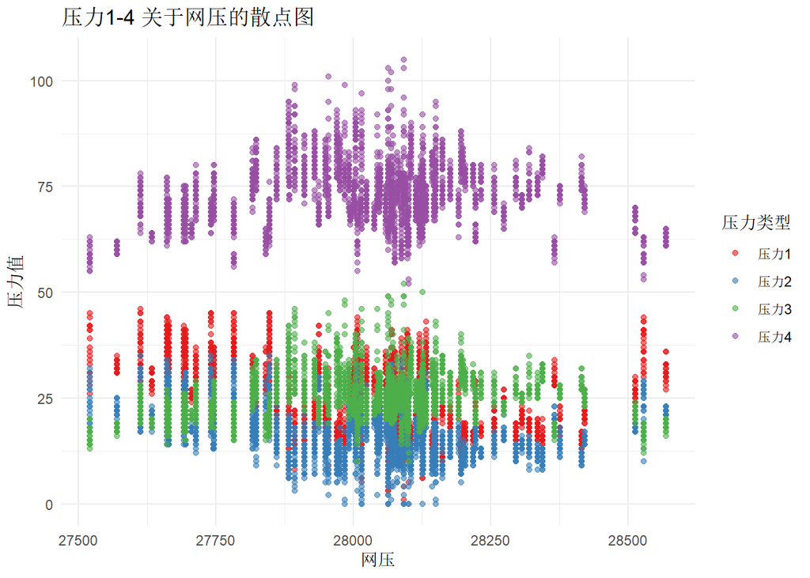

```r
ggplot(data_long %>% filter(Pressure_Value != 200), aes(x = 网压, y = Pressure_Value, color = Pressure_Type)) +
  geom_point(alpha = 0.6) +
  labs(
    title = "压力1-4 关于网压的散点图",
    x = "网压",
    y = "压力值",
    color = "压力类型"
  ) +
  theme_minimal() +
  scale_color_brewer(palette = "Set1")
```

#### 压力1-4与保留3

压力1与保留3的相关系数为-0.27

压力2与保留3的相关系数为-0.25

压力3与保留3的相关系数为0.14

压力4与保留3的相关系数为0.10

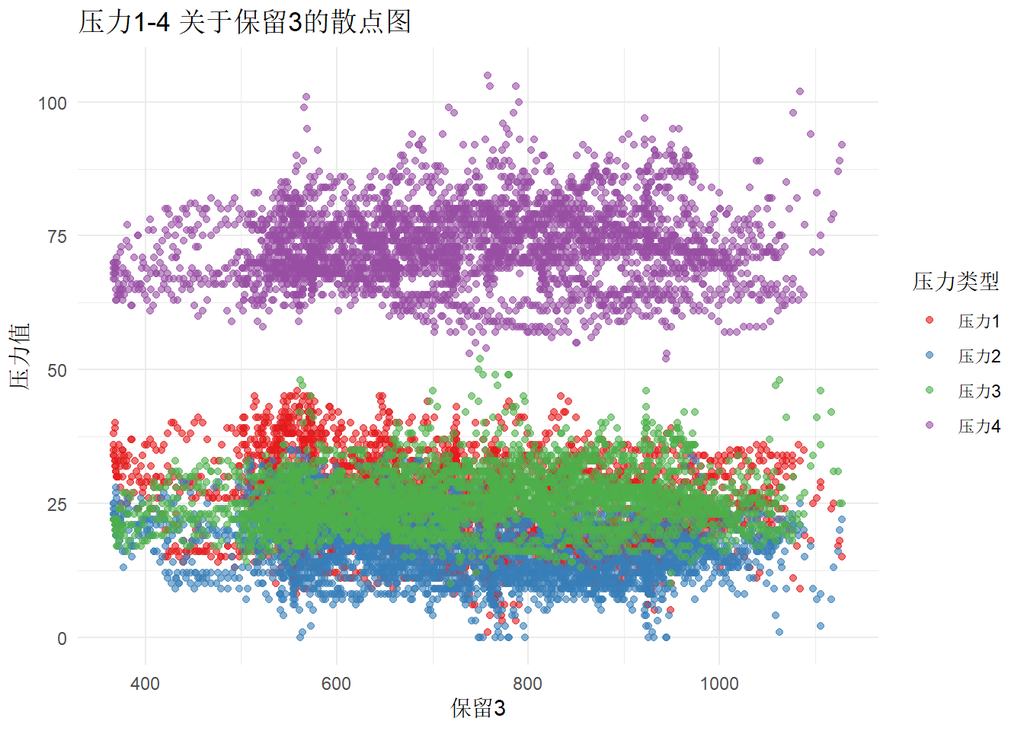

```r
ggplot(data_long %>% filter(Pressure_Value != 200), aes(x = 保留3, y = Pressure_Value, color = Pressure_Type)) +
  geom_point(alpha = 0.6) +
  labs(
    title = "压力1-4 关于保留3的散点图",
    x = "保留3",
    y = "压力值",
    color = "压力类型"
  ) +
  theme_minimal() +
  scale_color_brewer(palette = "Set1")
```

#### 压力1-4与保留4

压力1与保留4的相关系数为0.13

压力2与保留4的相关系数为0.11

压力3与保留4的相关系数为-0.14

压力4与保留4的相关系数为-0.13

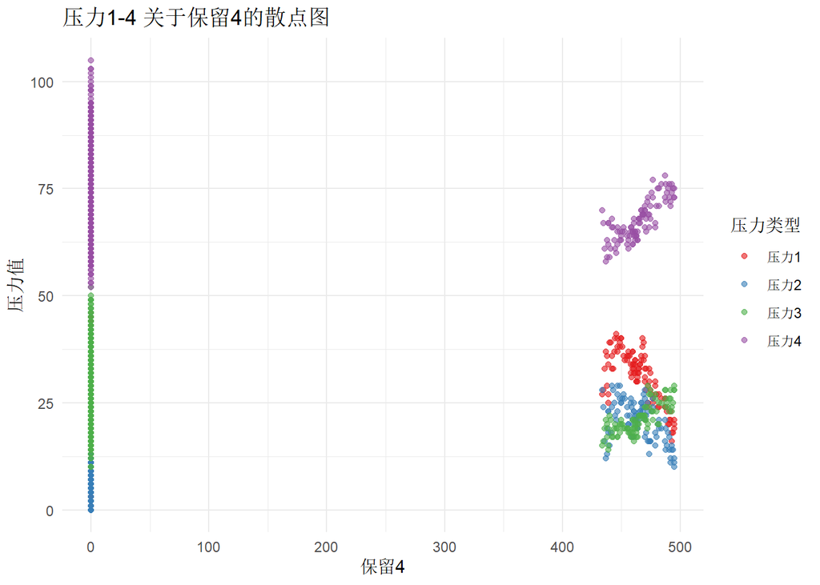

```r
ggplot(data_long %>% filter(Pressure_Value != 200), aes(x = 保留4, y = Pressure_Value, color = Pressure_Type)) +
  geom_point(alpha = 0.6) +
  labs(
    title = "压力1-4 关于保留4的散点图",
    x = "保留4",
    y = "压力值",
    color = "压力类型"
  ) +
  theme_minimal() +
  scale_color_brewer(palette = "Set1")
```

#### 压力1-4与非接触导高1

压力1与非接触导高1的相关系数为-0.42

压力2与非接触导高1的相关系数为-0.40

压力3与非接触导高1的相关系数为0.10

压力4与非接触导高1的相关系数为0

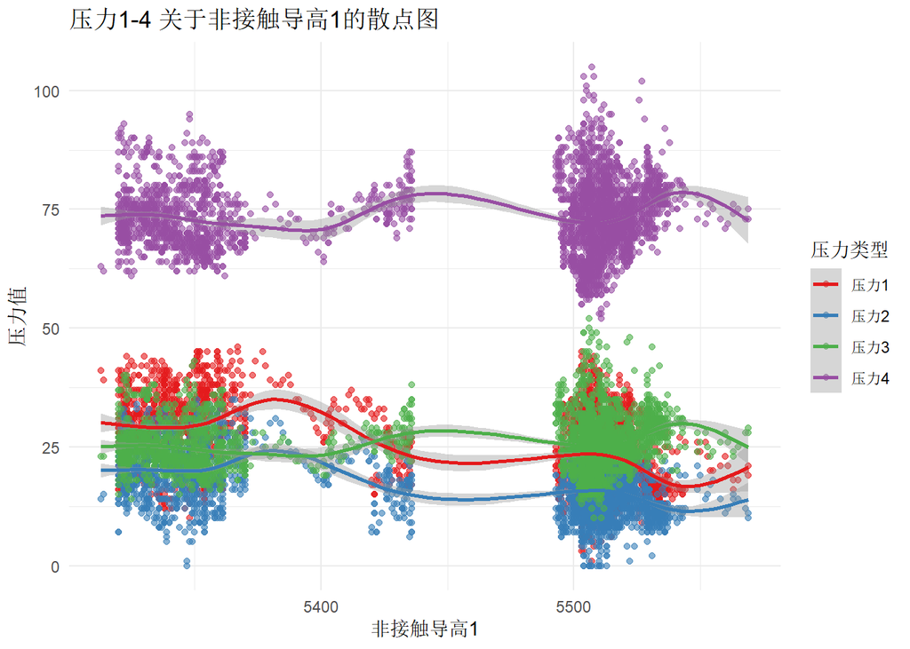

```r
ggplot(data_long %>% filter(Pressure_Value != 200), aes(x = 非接触导高1, y = Pressure_Value, color = Pressure_Type)) +
  geom_point(alpha = 0.6) +
  labs(
    title = "压力1-4 关于非接触导高1的散点图",
    x = "非接触导高1",
    y = "压力值",
    color = "压力类型"
  ) +
  theme_minimal() +
  scale_color_brewer(palette = "Set1")+
  geom_smooth()
```

#### 压力1-4与非接触导高2

压力1与非接触导高1的相关系数为-0.42

压力2与非接触导高1的相关系数为-0.40

压力3与非接触导高1的相关系数为0.09

压力4与非接触导高1的相关系数为0

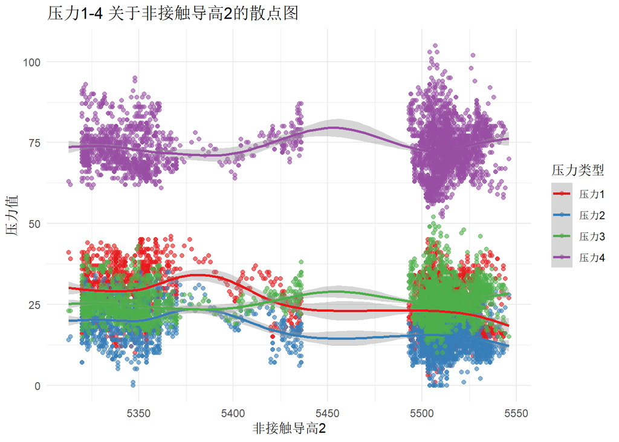

```r
ggplot(data_long %>% filter(Pressure_Value != 200), aes(x = 非接触导高2, y = Pressure_Value, color = Pressure_Type)) +
  geom_point(alpha = 0.6) +
  labs(
    title = "压力1-4 关于非接触导高2的散点图",
    x = "非接触导高2",
    y = "压力值",
    color = "压力类型"
  ) +
  theme_minimal() +
  scale_color_brewer(palette = "Set1")+
  geom_smooth()
```